# STAT3888 — Phase 4: Predictive modelling

Gordon | Machine learning assessment of PUFA:SFA, omega-3 and blood lipid status

Gordon

2026-10-18

# 1 Research question and prediction target

**Question:** Does adding the Day-1 PUFA:SFA ratio, alone or with an omega-3 composition proxy, improve the ability to classify **prevalent** elevated total cholesterol or elevated LDL in NNPAS 2011–12 biomedical respondents aged 18–64, beyond demographic, lifestyle and clinical predictors?

This is a **machine-learning classification** task, intentionally separate from the high-versus-low causal-methods analysis in `Phase4_03_Causal_analysis.Rmd`. The outcome is a *same-survey binary laboratory abnormality*, **not** subsequent cardiovascular events or future dyslipidaemia. No causal effect or clinical decision tool is identified.

# 2 Data and eligibility

The models use the 2,322-person fasting Phase 2 cohort and retain every participant with a nonmissing binary outcome and positive biomedical survey weight. The original 1,471-person high/low threshold analysis is not used as the training population. PUFA:SFA remains continuous to preserve exposure information. The two endpoints have different missingness and are evaluated separately.

```r
cohort$N <- as.integer(cohort$N)
cohort$cases <- as.integer(cohort$cases)
cohort$weighted_prevalence <- 100*cohort$weighted_prevalence
cohort$weighted_prevalence <- round(cohort$weighted_prevalence,1)
knitr::kable(cohort[, c('Outcome','N','cases','weighted_prevalence')],
             col.names=c('Binary outcome','N','Abnormal cases','Weighted prevalence (%)'),
             caption='Available labelled populations; all are fasting at least eight hours.')
```

Available labelled populations; all are fasting at least eight hours.

| Binary outcome | N | Abnormal cases | Weighted prevalence (%) |
| --- | --- | --- | --- |
| total_chol_elevated | 2321 | 872 | 33.6 |
| ldl_chol_elevated | 2291 | 850 | 34.2 |

**Excluded as predictors:** cholesterol/LDL result codes, binary lipid outcome flags, dyslipidaemia composite and medication-derived outcome proxies; these could reveal the outcome or distort validation. The same participant is never in the training and test subset of any outer fold.

# 3 Predictors and learning algorithms

| Predictor block | Variables | Rationale |
| --- | --- | --- |
| Baseline | Age, sex, BMI, current diabetes, SEIFA quintile, remoteness, smoking, weekly MVPA, Day-1 alcohol and total dietary energy | Demographic, lifestyle and clinical baseline |
| Added lipid ratio | Baseline plus continuous `log(1 + PUFA:SFA)` | Incremental information from fatty acid composition |
| Added omega-3 | Above plus the proxy omega-3 percentage of total PUFA (scaled per ten percentage points) | Incremental dietary composition information |

**Algorithms:** penalised logistic regression with an L2 penalty (**ridge classification**), and random forest classification as a nonlinear reference. Ridge models use three feature sets; forests compare baseline versus the full set. This ensures the *same algorithm and outer test folds* are used when attributing changes in prediction to the added diet variables. The base model already includes total dietary energy.

Numeric predictors are median-imputed and standardised using **training-only** estimates; categorical predictors are mode-imputed and one-hot encoded. Weekly MVPA, alcohol, energy and the fatty acid ratio receive `log1p` transformations. The transformations are applied identically to held-out rows, avoiding test-set leakage.

# 4 Validation and hyperparameter tuning

The reported numeric results were independently obtained using Python scikit-learn; the full source is included as `ml/train_validate.py`. An equivalent end-to-end **R implementation** is supplied below and may be executed by setting `rerun_independent_R_validation: true` in this Rmd’s YAML. Python and R use separate random-number generators and regularisation conventions, so their numerical results need not be identical.

- **Ridge:** five stratified outer folds, repeated twice, with three inner folds for choosing the L2 penalty (`C = 0.03, 0.3, 3`). Ten outer-fold estimates per endpoint and predictor specification.
- **Random forest:** five stratified outer folds, three inner folds for minimum leaf size (`12, 30`); 110 trees per fitted forest.
- All training models use normalised positive biomedical survey weights; test ROC-AUC, Brier score and log loss are survey-weighted.
- Candidate tuning occurs **only inside each training fold**. Each test fold remains untouched until evaluation.

Ridge and random forest outer averages should **not** be treated as inferential confidence intervals. Repeated test folds overlap, and stratified random cross-validation does not fully capture clustered/stratified survey-design uncertainty.

# 5 Main predictive performance

```r
show <- score[,c('Outcome','Algorithm','Features','AUC','Brier','LogLoss','Folds')]
show$AUC <- round(show$AUC,3);show$Brier<-round(show$Brier,3)
show$LogLoss<-round(show$LogLoss,3)
show <- show[order(show$Outcome,show$Algorithm,show$Features),]
knitr::kable(show, caption='Mean survey-weighted outer-test performance. Higher AUC and lower Brier/log loss are better.')
```

Mean survey-weighted outer-test performance. Higher AUC and lower Brier/log loss are better.

| Outcome | Algorithm | Features | AUC | Brier | LogLoss | Folds |
| --- | --- | --- | --- | --- | --- | --- |
| ldl_chol_elevated | Random forest | Baseline | 0.682 | 0.205 | 0.596 | 5 |
| ldl_chol_elevated | Random forest | Baseline + PUFA:SFA + omega-3 | 0.671 | 0.208 | 0.601 | 5 |
| ldl_chol_elevated | Ridge logistic | Baseline | 0.695 | 0.205 | 0.595 | 10 |
| ldl_chol_elevated | Ridge logistic | Baseline + PUFA:SFA | 0.693 | 0.205 | 0.596 | 10 |
| ldl_chol_elevated | Ridge logistic | Baseline + PUFA:SFA + omega-3 | 0.692 | 0.206 | 0.596 | 10 |
| total_chol_elevated | Random forest | Baseline | 0.687 | 0.203 | 0.592 | 5 |
| total_chol_elevated | Random forest | Baseline + PUFA:SFA + omega-3 | 0.677 | 0.205 | 0.597 | 5 |
| total_chol_elevated | Ridge logistic | Baseline | 0.688 | 0.205 | 0.594 | 10 |
| total_chol_elevated | Ridge logistic | Baseline + PUFA:SFA | 0.687 | 0.205 | 0.595 | 10 |
| total_chol_elevated | Ridge logistic | Baseline + PUFA:SFA + omega-3 | 0.685 | 0.205 | 0.596 | 10 |

Baseline ridge discrimination was approximately **0.688 for elevated total cholesterol** and **0.695 for elevated LDL**. Predictive discrimination is moderate, and there is no external validation. A model with AUC around 0.69 is not suitable for clinical screening on this evidence alone.

# 6 Incremental predictive contribution of PUFA:SFA and omega-3

```r
change <- delta[,c('Outcome','Algorithm','Added','mean_delta_AUC','folds_improved_AUC','folds','mean_delta_Brier')]
change$mean_delta_AUC <- round(change$mean_delta_AUC,4)
change$mean_delta_Brier <- round(change$mean_delta_Brier,4)
knitr::kable(change,caption='Paired comparison against the corresponding baseline model. Positive delta AUC and negative delta Brier indicate improvement.')
```

Paired comparison against the corresponding baseline model. Positive delta AUC and negative delta Brier indicate improvement.

| Outcome | Algorithm | Added | mean_delta_AUC | folds_improved_AUC | folds | mean_delta_Brier |
| --- | --- | --- | --- | --- | --- | --- |
| ldl_chol_elevated | Random forest | Baseline + PUFA:SFA + omega-3 | -0.0110 | 1 | 5 | 0.0024 |
| ldl_chol_elevated | Ridge logistic | Baseline + PUFA:SFA | -0.0016 | 4 | 10 | 0.0004 |
| ldl_chol_elevated | Ridge logistic | Baseline + PUFA:SFA + omega-3 | -0.0023 | 4 | 10 | 0.0006 |
| total_chol_elevated | Random forest | Baseline + PUFA:SFA + omega-3 | -0.0101 | 0 | 5 | 0.0020 |
| total_chol_elevated | Ridge logistic | Baseline + PUFA:SFA | -0.0005 | 4 | 10 | 0.0001 |
| total_chol_elevated | Ridge logistic | Baseline + PUFA:SFA + omega-3 | -0.0030 | 0 | 10 | 0.0006 |

Adding the dietary composition variables **did not improve average held-out AUC or Brier score** for either target in the tested specifications. Ridge with PUFA:SFA alone changed mean AUC by approximately -5e-04 for total cholesterol and -0.0016 for LDL. The fully dietary-augmented ridge models performed slightly worse on average. This speaks to incremental **prediction in this model/validation scheme**; it does not establish that PUFA or omega-3 have no biological effects.

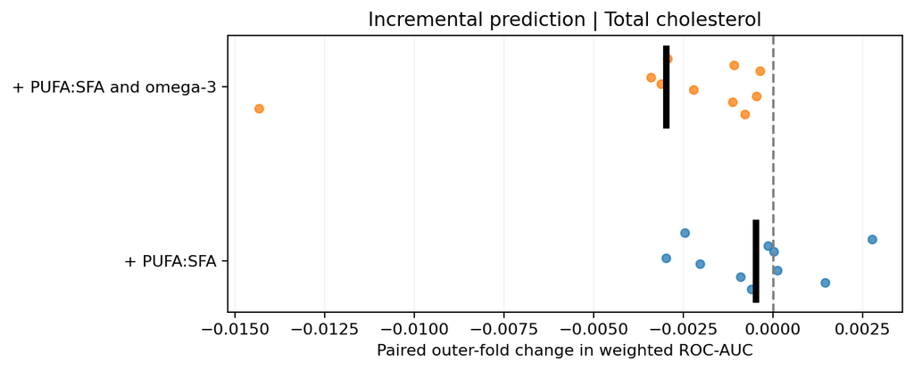

Paired ten-fold weighted AUC changes in ridge predictions when dietary composition is added to the baseline.

```r
knitr::include_graphics(file.path(figure_dir,'delta_total_chol_elevated.png'))
```

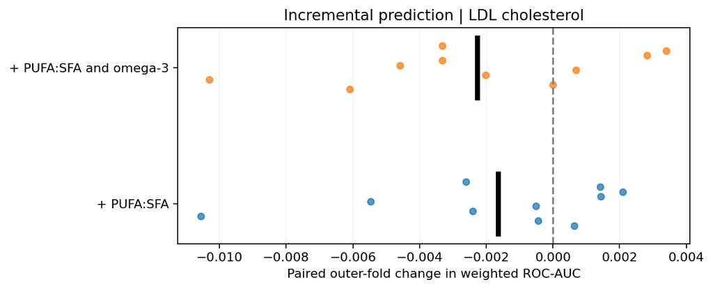

Paired ten-fold weighted AUC changes in ridge predictions when dietary composition is added to the baseline.

```r
knitr::include_graphics(file.path(figure_dir,'delta_ldl_chol_elevated.png'))
```

# 7 Discrimination and probability calibration

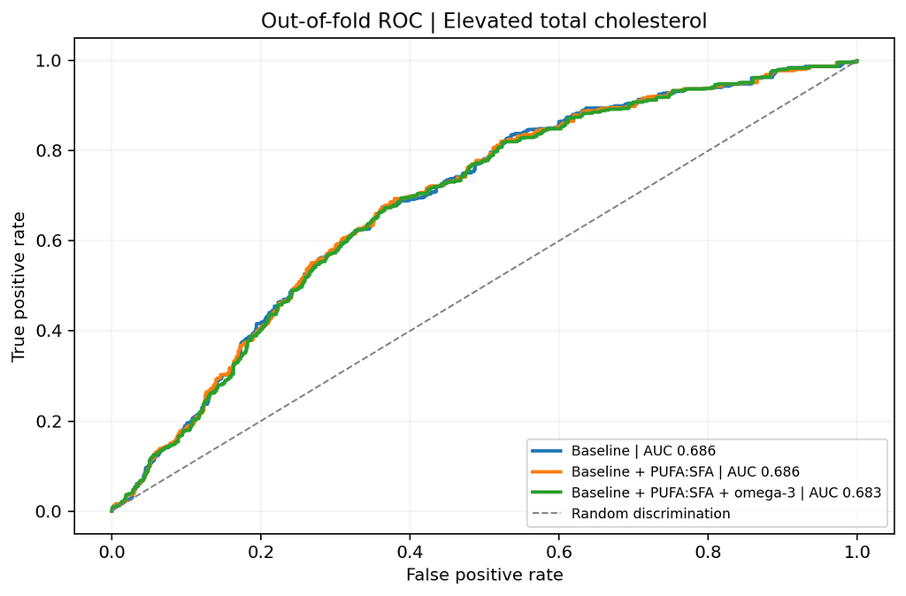

Representative pooled out-of-fold ROC curves. Each observation was predicted from a model whose training data excluded that observation.

```r
knitr::include_graphics(file.path(figure_dir,'roc_total_chol_elevated.png'))
```

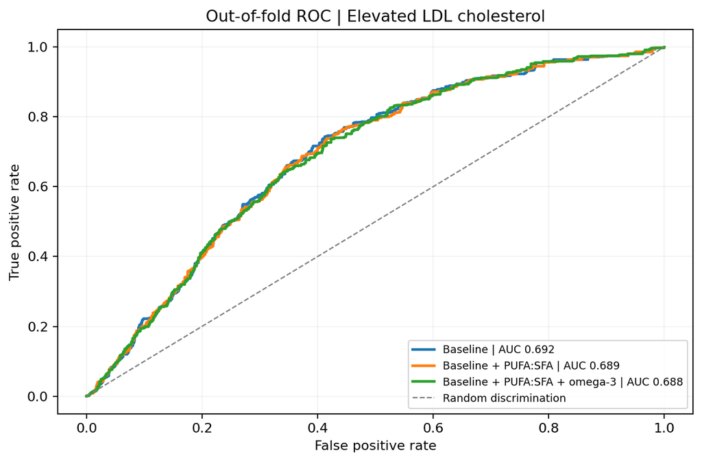

Representative pooled out-of-fold ROC curves. Each observation was predicted from a model whose training data excluded that observation.

```r
knitr::include_graphics(file.path(figure_dir,'roc_ldl_chol_elevated.png'))
```

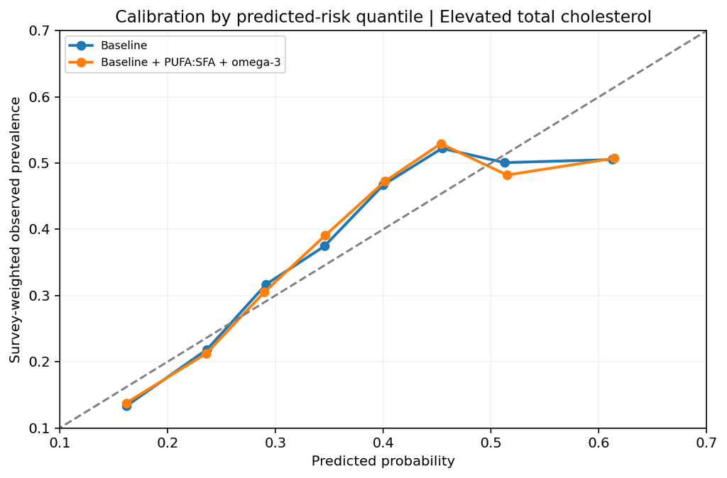

Eight weighted prediction-risk groups; deviations from the diagonal indicate imperfect calibration. This is an exploratory calibration display.

```r
knitr::include_graphics(file.path(figure_dir,'calibration_total_chol_elevated.png'))
```

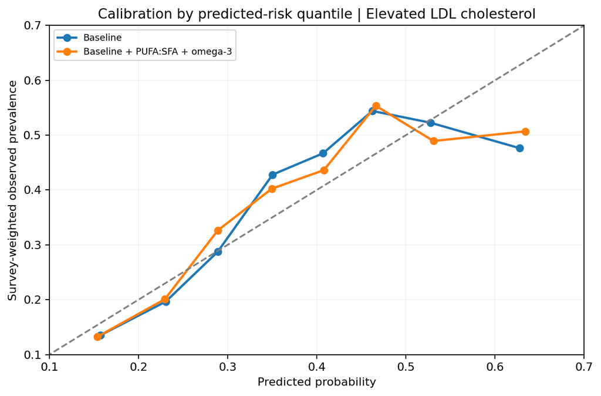

Eight weighted prediction-risk groups; deviations from the diagonal indicate imperfect calibration. This is an exploratory calibration display.

```r
knitr::include_graphics(file.path(figure_dir,'calibration_ldl_chol_elevated.png'))
```

# 8 Connection to the STAT3888 group analyses

**Stacy:** models saturated fat as percentage of energy and four lipid endpoints. The current machine-learning model tests the *incremental predictive utility* of PUFA:SFA and omega-3, not Stacy’s specific saturated-fat treatment comparison. Direct benchmark comparison would require common endpoints, identical eligible participants and cross-validation folds.

**Thomas:** has already separated association from prediction and estimated incremental performance for a fibre-to-carbohydrate ratio using ridge and cross-validation. The present results use a similar analytical question, but a different fasting-only sample and different baseline covariates; raw AUC levels should not be compared as if identical test populations had been used.

# 9 Limitations, interpretation and improvement

1. **Cross-sectional measurement:** all labels describe current lipid abnormality; this is not temporal disease prediction.
2. **Selection:** Phase 2 participants are already limited to an available fasting biomedical subset, potentially affecting transportability. Absence of an independent NNPAS holdout or external cohort prevents claims about generalisation.
3. **Classifiers:** adding a variable can fail to improve prediction even when it has a biologically plausible association. This is an observation about *incremental predictive performance*, not proof of no effect.
4. **Weights:** biomedical survey weights were incorporated; outer-fold AUC variability is not a survey-design confidence interval. A planned improvement is to assess uncertainty using appropriate design-aware validation.
5. **Measurement error and missingness:** dietary variables represent a single recall day; missing BMI and MVPA values are imputed from training data only; class probabilities may need separate external calibration.
6. **Comparability:** harmonise eligible participants, outcome definitions, core predictors and folds with Stacy/Thomas before using cross-workstream comparisons in a final combined conclusion.

**Conclusion:** Using the available Phase 2 fasting sample, ridge and random forest yielded moderate internal discrimination but no observed gain from adding Day-1 PUFA:SFA and omega-3 composition measures. The most defensible interpretation is limited added predictive information *beyond this baseline, in this cohort*, not the absence of dietary relevance.

# 10 Optional independent R re-estimation

The following chunk contains a self-contained R machine-learning workflow. It is disabled by default so the report can Knit using the **verified output tables** without requiring modelling packages. Set `rerun_independent_R_validation: true` at the beginning of this file to execute a second nested-CV analysis in R. It writes `r_reestimated_outer_fold_metrics.csv` and a summary under `ml/tables` without altering the independently verified Python tables.

```r
if (!requireNamespace('glmnet',quietly=TRUE)) stop('install.packages("glmnet")')
if (!requireNamespace('ranger',quietly=TRUE)) stop('install.packages("ranger")')
x <- read.csv(file.path(ml_dir,'ML_analysis_ready.csv'), stringsAsFactors=FALSE)
for (col in c('mvpa_equiv_min_week','alcohol_g_day1','energy_kj_day1','pufa_sfa_ratio'))
  x[[paste0('log1p_',col)]] <- log1p(x[[col]])
x$omega3_per10 <- x$omega3_proxy_pct_pufa/10
cats <- c('sex','seifa_quintile','remoteness','smoking3')
num_base <- c('age','bmi','diabetes_current','log1p_mvpa_equiv_min_week',
              'log1p_alcohol_g_day1','log1p_energy_kj_day1')
set_base <- c(num_base,cats)
sets <- list(Baseline=set_base, Ratio=c(set_base,'log1p_pufa_sfa_ratio'),
  FullDiet=c(set_base,'log1p_pufa_sfa_ratio','omega3_per10'))
# Weighted rank AUC. Continuous ridge/RF scores make exact ties uncommon.
w_auc <- function(y,p,w){
  ix <- order(p);y <- y[ix];w <- w[ix]
  wp <- ifelse(y==1,w,0);wn<-ifelse(y==0,w,0)
  sum(wp * (cumsum(wn)-0.5*wn)) / (sum(wp)*sum(wn))
}
w_brier <- function(y,p,w) weighted.mean((y-p)^2,w)
makefolds <- function(y,k=5,seed=1){
  set.seed(seed); fold <- integer(length(y))
  for (v in 0:1){ ids <- sample(which(y==v)); fold[ids] <- rep(seq_len(k),length.out=length(ids)) }
  fold
}
# Fit and apply preprocessing using TRAINING data only.
encode <- function(train,test,features){
  a <- train[,features,drop=FALSE];b <- test[,features,drop=FALSE]
  for (v in intersect(cats,features)){
    a[[v]][is.na(a[[v]])] <- 'Missing'; b[[v]][is.na(b[[v]])] <- 'Missing'
    lev <- sort(unique(c(as.character(a[[v]]),as.character(b[[v]]))))
    a[[v]] <- factor(a[[v]],levels=lev);b[[v]] <- factor(b[[v]],levels=lev)
  }
  for(v in setdiff(features,cats)){
    med <- median(a[[v]],na.rm=TRUE)
    if(!is.finite(med)) med<-0
    a[[v]][!is.finite(a[[v]])] <- med
    b[[v]][!is.finite(b[[v]])] <- med
  }
  mm <- function(z) model.matrix(~ . -1,data=z)
  list(xt=mm(a), xv=mm(b))
}
fitpredict <- function(tr,te,features,method,param){
  z <- encode(tr,te,features)
  yy <- as.integer(tr$.y);w <- tr$.w / mean(tr$.w)
  if (method=='Ridge'){
    model <- glmnet::glmnet(z$xt,yy,alpha=0,family='binomial',lambda=param,
                            weights=w,standardize=TRUE)
    as.numeric(predict(model,newx=z$xv,s=param,type='response'))
  }else{
    zz <- data.frame(response=factor(yy,levels=c(0,1)),z$xt,check.names=TRUE)
    model <- ranger::ranger('response',data=zz,probability=TRUE,num.trees=110,
                             min.node.size=param,case.weights=w,seed=2026)
    vv <- data.frame(z$xv,check.names=TRUE)
    as.numeric(predict(model,data=vv)$predictions[,'1'])
  }
}
reestimate <- list()
for (target in c('total_chol_elevated','ldl_chol_elevated')){
  d <- x[!is.na(x[[target]]) & is.finite(x$NHMSPERW) & x$NHMSPERW>0,]
  d$.y<-as.integer(d[[target]]); d$.w<-d$NHMSPERW
  for (method in c('Ridge','Forest')){
    blocks <- if(method=='Ridge') names(sets) else c('Baseline','FullDiet')
    repeats <- if(method=='Ridge') 2 else 1
    opts <- if(method=='Ridge') c(.001,.01,.1,1) else c(12,30)
    for (rr in seq_len(repeats)){
      oo <- makefolds(d$.y,5,3888+rr)
      for (kk in seq_len(5)){
        tr <- d[oo!=kk,];te <- d[oo==kk,]
        inner <- makefolds(tr$.y,3,211+kk+10*rr)
        for (name in blocks){
          features <- sets[[name]]
          tuning <- sapply(opts,function(v){
            as.numeric(mean(sapply(seq_len(3),function(j){
              aa<-tr[inner!=j,];bb<-tr[inner==j,]
              pr<-fitpredict(aa,bb,features,method,v)
              w_auc(bb$.y,pr,bb$.w)
            })))
          })
          selected <- opts[which.max(tuning)]
          pred <- fitpredict(tr,te,features,method,selected)
          reestimate[[length(reestimate)+1]] <- data.frame(
            Outcome=target,Algorithm=method,Features=name,Repeat=rr,Fold=kk,
            AUC=w_auc(te$.y,pred,te$.w),Brier=w_brier(te$.y,pred,te$.w),Hyperparameter=selected)
        }
      }
    }
  }
}
rr <- do.call(rbind,reestimate)
write.csv(rr,file.path(table_dir,'r_reestimated_outer_fold_metrics.csv'),row.names=FALSE)
rr_summary <- aggregate(cbind(AUC,Brier)~Outcome+Algorithm+Features,data=rr,FUN=mean)
write.csv(rr_summary,file.path(table_dir,'r_reestimated_model_summary.csv'),row.names=FALSE)
knitr::kable(rr_summary,digits=4,caption='Independent R re-estimation; random folds and tuning differ from the Python verification.')
```

# 11 Practical use of a fitted classifier

After completing cross-validation, the accompanying `ml/fit_predict.py` fits final ridge models on **all labelled data**. These are saved in `ml/models` for exploratory classification of other records using the same variables and coding. Use only the out-of-fold results above to assess performance. To produce probability columns for new compatible input rows:

```
python ml/fit_predict.py --predict ml/example_predictors.csv --output ml/predicted_probabilities.csv
```

The models require age, BMI, current diabetes, sex, SEIFA, remoteness, smoking, MVPA, alcohol, energy, PUFA:SFA and omega-3 percentage. They do not predict subsequent illness and are **not validated for personal medical assessment**.